# Module 150

#### Hemi-module gene counts:

238 probesets in hemi-module A.  
270 probesets in hemi-module B.  
Note: While the mapping of probesets to genes is usually one-to-one, some genes are targeted by multiple probesets, some probesets target multiple genes, and some probesets do not target any genes (i.e., the region of the genome they match is no longer considered genic).

#### Contrast SVE:

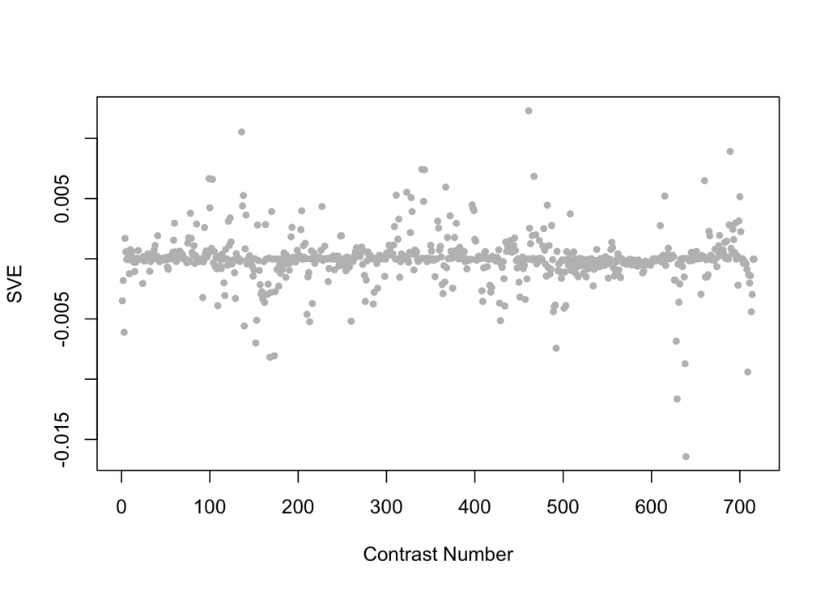

Positive SVE Contrasts:

|  | Contrast.Num | SVE | GEO.GSE | Cond.1 | Cond.2 | Mutation |
| --- | --- | --- | --- | --- | --- | --- |
| GSE23528A.s1t3.vs.s0t3 | 461 | 0.01 | GSE23528 | Adult at T10 in LD, time-series experiment 3 | Adult at T10, non-entrained control time-series experiment 4 |  |
| GSE51691.s2t1.vs.s1t1 | 136 | 0.01 | GSE51691 | day8 hermaphrodite +males rep 1 | day8 hermaphrodite -males rep 1 |  |
| GSE11055.s1t3.vs.s2t3 | 689 | 0.01 | GSE11055 | L1 larvae 1 hr after hatching in the presence of food | L1 larvae 1 hr after hatching in the absence of food |  |
| GSE38997.s4t1.vs.s1t1 | 340 | 0.01 | GSE38997 | experiment 4 UVC-exposed samples at 3 h 4u3 | experiment 4 control samples at 3 h 4c3 |  |
| GSE38997.s4t1.vs.s3t1 | 343 | 0.01 | GSE38997 | experiment 4 UVC-exposed samples at 3 h 4u3 | experiment 4 UVC- and EtBr-exposed samples at 3 h 4eu3 |  |

Negative SVE Contrasts:

|  | Contrast.Num | SVE | GEO.GSE | Cond.1 | Cond.2 | Mutation |
| --- | --- | --- | --- | --- | --- | --- |
| GSE18132.s1t1.vs.s0t1 | 639 | -0.02 | GSE18132 | Ogt starved L1, biological replicate 1 | WT Starved L1, biological rep1 | ogt-1 |
| GSE19310A.s2t1.vs.s0t1 | 629 | -0.01 | GSE19310 | osm-7(n1515) at iso, rep1 | N2 at iso, rep1 | osm-7 |
| GSE11055.s2t3.vs.s2t2 | 709 | -0.01 | GSE11055 | L1 larvae 1 hr after hatching in the absence of food | L1 larvae 0 hr after hatching in the absence of food |  |
| GSE18132.s2t1.vs.s0t1 | 638 | -0.01 | GSE18132 | Oga starved L1, biological replicate 1 | WT Starved L1, biological rep1 | oga-1 |
| GSE47778.s1t3.vs.s3t3 | 168 | -0.01 | GSE47778 | N2; UV; replicate 1 | daf-16; UV; replicate 1 | daf-16 |

$~$

#### Contrast SVE, Up-Regulated Genes Only:

Calculating SVE for up-regulated and down-regulated genes separately may be more informative in many cases than projecting the up- and down- gene sets together. This is due to the fact that the weight distribution of many modules is highly skewed, indicating that only one of the hemi-modules may be biologically meaningful (i.e., a set of genes are strongly correlated by only a few genes (or none) are strongly anti-correlated to that set.)

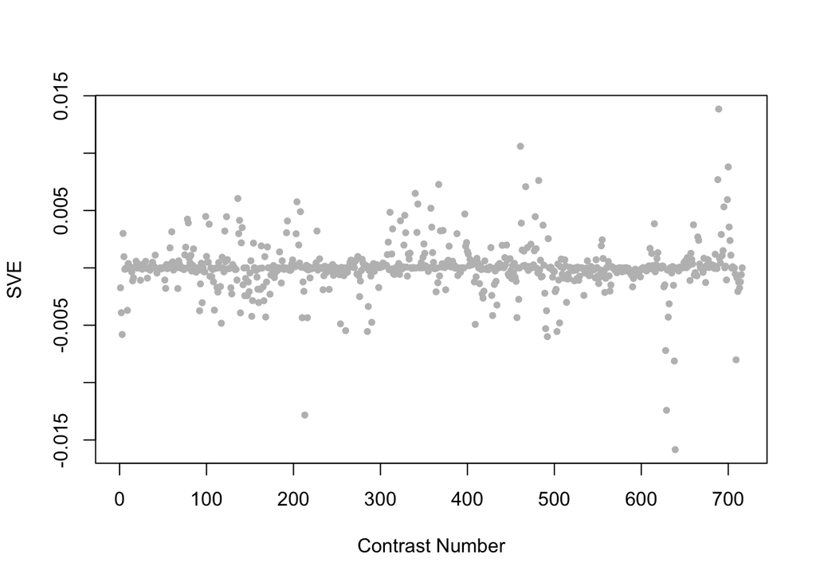

Positive SVE Contrasts:

|  | Contrast.Num | SVE | GEO.GSE | Cond.1 | Cond.2 | Mutation |
| --- | --- | --- | --- | --- | --- | --- |
| GSE11055.s1t3.vs.s2t3 | 689 | 0.01 | GSE11055 | L1 larvae 1 hr after hatching in the presence of food | L1 larvae 1 hr after hatching in the absence of food |  |
| GSE23528A.s1t3.vs.s0t3 | 461 | 0.01 | GSE23528 | Adult at T10 in LD, time-series experiment 3 | Adult at T10, non-entrained control time-series experiment 4 |  |
| GSE11055.s1t4.vs.s3t4 | 700 | 0.01 | GSE11055 | L1 larvae 3 hr after hatching in the presence of food | L1 larvae 3 hr after hatching in the absence of food in the alternative starvation buffer M9 |  |
| GSE11055.s1t2.vs.s2t2 | 688 | 0.01 | GSE11055 | L1 larvae 0 hr after hatching in the presence of food | L1 larvae 0 hr after hatching in the absence of food |  |
| GSE23528A.s2t2.vs.s2t1 | 482 | 0.01 | GSE23528 | Adult at T6 in WC, time-series experiment 1 | Adult at T2 in WC, time-series experiment 1 |  |

Negative SVE Contrasts:

|  | Contrast.Num | SVE | GEO.GSE | Cond.1 | Cond.2 | Mutation |
| --- | --- | --- | --- | --- | --- | --- |
| GSE18132.s1t1.vs.s0t1 | 639 | -0.02 | GSE18132 | Ogt starved L1, biological replicate 1 | WT Starved L1, biological rep1 | ogt-1 |
| GSE42689.s4t1.vs.s2t1 | 213 | -0.01 | GSE42689 | mlk-1 fed 1 | mek-1 fed 1 |  |
| GSE19310A.s2t1.vs.s0t1 | 629 | -0.01 | GSE19310 | osm-7(n1515) at iso, rep1 | N2 at iso, rep1 | osm-7 |
| GSE18132.s2t1.vs.s0t1 | 638 | -0.01 | GSE18132 | Oga starved L1, biological replicate 1 | WT Starved L1, biological rep1 | oga-1 |
| GSE11055.s2t3.vs.s2t2 | 709 | -0.01 | GSE11055 | L1 larvae 1 hr after hatching in the absence of food | L1 larvae 0 hr after hatching in the absence of food |  |

$~$

#### Contrast SVE, Down-Regulated Genes Only:

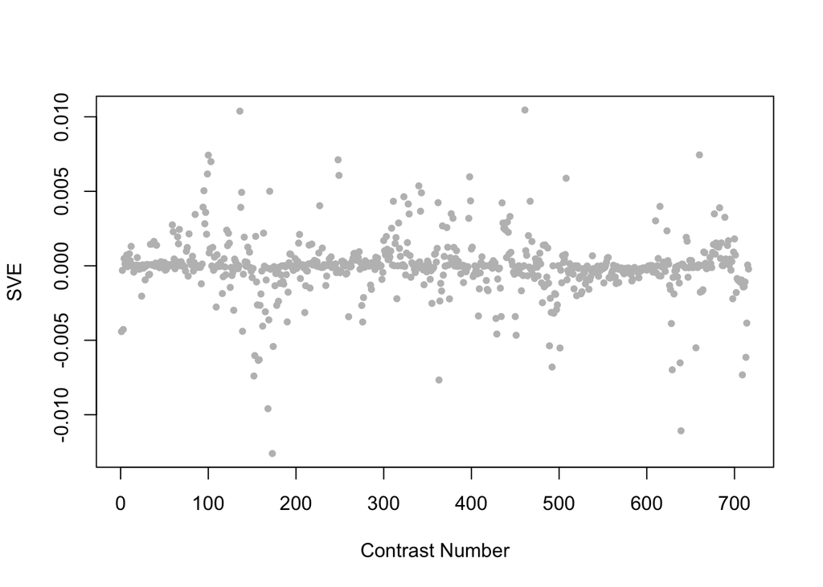

Positive SVE Contrasts:

|  | Contrast.Num | SVE | GEO.GSE | Cond.1 | Cond.2 | Mutation |
| --- | --- | --- | --- | --- | --- | --- |
| GSE23528A.s1t3.vs.s0t3 | 461 | 0.01 | GSE23528 | Adult at T10 in LD, time-series experiment 3 | Adult at T10, non-entrained control time-series experiment 4 |  |
| GSE51691.s2t1.vs.s1t1 | 136 | 0.01 | GSE51691 | day8 hermaphrodite +males rep 1 | day8 hermaphrodite -males rep 1 |  |
| GSE15527.s2t1.vs.s1t1 | 660 | 0.01 | GSE15527 | sma-6 L4 worm, biological rep1 | dbl-1 L4 worm, biological rep1 | dbl-1 |
| GSE5793.s3t2.vs.s2t2 | 100 | 0.01 | GSE5793 | Celegans_PA14_8hours_RepA | Celegans_OP50_8hours_RepA |  |
| GSE42192.s1t2.vs.s0t2 | 248 | 0.01 | GSE42192 | C.elegans fed with CNCM I-3690 10 days rep1 | C.elegans fed with E.coli OP50 10 days rep1 |  |

Negative SVE Contrasts:

|  | Contrast.Num | SVE | GEO.GSE | Cond.1 | Cond.2 | Mutation |
| --- | --- | --- | --- | --- | --- | --- |
| GSE47778.s1t3.vs.s4t3 | 173 | -0.01 | GSE47778 | N2; UV; replicate 1 | daf-2;daf-16; UV; replicate 1 | daf-2;daf-16 |
| GSE18132.s1t1.vs.s0t1 | 639 | -0.01 | GSE18132 | Ogt starved L1, biological replicate 1 | WT Starved L1, biological rep1 | ogt-1 |
| GSE47778.s1t3.vs.s3t3 | 168 | -0.01 | GSE47778 | N2; UV; replicate 1 | daf-16; UV; replicate 1 | daf-16 |
| GSE36358.s2t1.vs.s0t1 | 363 | -0.01 | GSE36358 | Clino Rotation | Ground Control (Tsukuba space center) |  |
| GSE47778.s1t1.vs.s3t1 | 152 | -0.01 | GSE47778 | N2; replicate 1 | daf-16; replicate 1 | daf-16 |

$~$

$~$

#### GO Term Enrichment:

This analysis tests each hemi-module for enrichment of specific GO terms. Only gene-level annotations (e.g., as would be found on the gene’s page in Wormbase) are tested - the hierarchical structure of the GO ontology is not taken into account.

*Note: At least the top two most enriched terms from each GO domain (BP/MF/CC) are shown, even when not statistically significant.*

##### Enriched GO terms: Hemi-module A

| ID | GO.Term | GO Domain | Raw p-value | Adj p-value |
| --- | --- | --- | --- | --- |
| [GO_0006644](http://amigo.geneontology.org/amigo/term/GO:0006644) | phospholipid metabolic process | BP | 1.21e-04 | 4.05e-01 |
| [GO_0055114](http://amigo.geneontology.org/amigo/term/GO:0055114) | oxidation-reduction process | BP | 2.23e-04 | 4.05e-01 |
| [GO_0008194](http://amigo.geneontology.org/amigo/term/GO:0008194) | UDP-glycosyltransferase activity | MF | 1.41e-06 | 2.88e-03 |
| [GO_0016758](http://amigo.geneontology.org/amigo/term/GO:0016758) | transferase activity, transferring hexosyl groups | MF | 3.10e-06 | 3.17e-03 |
| [GO_0020037](http://amigo.geneontology.org/amigo/term/GO:0020037) | heme binding | MF | 1.23e-05 | 8.40e-03 |
| [GO_0016705](http://amigo.geneontology.org/amigo/term/GO:0016705) | oxidoreductase activity, acting on paired donors, with incorporation or reduction of molecular oxygen | MF | 6.30e-05 | 3.22e-02 |
| [GO_0005506](http://amigo.geneontology.org/amigo/term/GO:0005506) | iron ion binding | MF | 8.07e-05 | 3.30e-02 |
| [GO_0004497](http://amigo.geneontology.org/amigo/term/GO:0004497) | monooxygenase activity | MF | 1.24e-04 | 4.23e-02 |
| [GO_0016491](http://amigo.geneontology.org/amigo/term/GO:0016491) | oxidoreductase activity | MF | 2.43e-04 | 6.27e-02 |
| [GO_0016788](http://amigo.geneontology.org/amigo/term/GO:0016788) | hydrolase activity, acting on ester bonds | MF | 2.46e-04 | 6.27e-02 |
| [GO_0004620](http://amigo.geneontology.org/amigo/term/GO:0004620) | phospholipase activity | MF | 2.97e-04 | 6.74e-02 |
| [GO_0043231](http://amigo.geneontology.org/amigo/term/GO:0043231) | intracellular membrane-bounded organelle | CC | 1.12e-04 | 1.04e-01 |
| [GO_0005780](http://amigo.geneontology.org/amigo/term/GO:0005780) | extrinsic component of intraperoxisomal membrane | CC | 1.25e-02 | 9.92e-01 |

##### Enriched GO terms: Hemi-module B

| ID | GO.Term | GO Domain | Raw p-value | Adj p-value |
| --- | --- | --- | --- | --- |
| [GO_0009410](http://amigo.geneontology.org/amigo/term/GO:0009410) | response to xenobiotic stimulus | BP | 8.05e-08 | 1.22e-04 |
| [GO_0006082](http://amigo.geneontology.org/amigo/term/GO:0006082) | organic acid metabolic process | BP | 1.01e-07 | 1.22e-04 |
| [GO_0042738](http://amigo.geneontology.org/amigo/term/GO:0042738) | exogenous drug catabolic process | BP | 1.01e-07 | 1.22e-04 |
| [GO_0006805](http://amigo.geneontology.org/amigo/term/GO:0006805) | xenobiotic metabolic process | BP | 1.51e-07 | 1.37e-04 |
| [GO_0045087](http://amigo.geneontology.org/amigo/term/GO:0045087) | innate immune response | BP | 3.67e-07 | 2.68e-04 |
| [GO_0055114](http://amigo.geneontology.org/amigo/term/GO:0055114) | oxidation-reduction process | BP | 2.08e-05 | 1.26e-02 |
| [GO_0005506](http://amigo.geneontology.org/amigo/term/GO:0005506) | iron ion binding | MF | 9.26e-08 | 8.41e-05 |
| [GO_0008395](http://amigo.geneontology.org/amigo/term/GO:0008395) | steroid hydroxylase activity | MF | 1.01e-07 | 8.41e-05 |
| [GO_0016712](http://amigo.geneontology.org/amigo/term/GO:0016712) | oxidoreductase activity, acting on paired donors, with incorporation or reduction of molecular oxygen, reduced flavin or flavoprotein as one donor, and incorporation of one atom of oxygen | MF | 1.23e-07 | 8.41e-05 |
| [GO_0016705](http://amigo.geneontology.org/amigo/term/GO:0016705) | oxidoreductase activity, acting on paired donors, with incorporation or reduction of molecular oxygen | MF | 2.62e-07 | 1.34e-04 |
| [GO_0004497](http://amigo.geneontology.org/amigo/term/GO:0004497) | monooxygenase activity | MF | 6.38e-06 | 2.61e-03 |
| [GO_0020037](http://amigo.geneontology.org/amigo/term/GO:0020037) | heme binding | MF | 5.11e-05 | 1.74e-02 |
| [GO_0016491](http://amigo.geneontology.org/amigo/term/GO:0016491) | oxidoreductase activity | MF | 1.28e-04 | 3.73e-02 |
| [GO_0043231](http://amigo.geneontology.org/amigo/term/GO:0043231) | intracellular membrane-bounded organelle | CC | 1.37e-05 | 1.27e-02 |
| [GO_0031674](http://amigo.geneontology.org/amigo/term/GO:0031674) | I band | CC | 9.06e-03 | 9.89e-01 |

$~$

$~$

#### Tissue Enrichment:

This analysis tests each hemi-module for enrichment of genes associated with anatomy terms. Negative enrichment scores indicate fewer hemi-module genes than expected by random chance were associated with the anatomy term in question.

##### Enriched tissues: Hemi-module A

No significant annotations.

##### Enriched tissues: Hemi-module B

No significant annotations.

$~$

$~$

#### HOMER promoter motif enrichment:

This analysis tests each hemi-module for enrichment of 108 known *C. elegans* transcription factor binding site motifs (see [108 CE motifs](https://katiepod.github.io//all.worm.motifs.html)) using the HOMER (Hypergeometric Optimization of Motif EnRichment) software (see [PMID:20513432](https://pubmed.ncbi.nlm.nih.gov/20513432)). HOMER was run using default parameters on sequences 1 kb upstream of the transcription start site.

##### Motif enrichment: Hemi-module A

Total target sequences = 223  
Total background sequences = 40643  
* - possible false positive

Rank

Motif

P-value

log P-pvalue

% of Targets

% of Background

STD(Bg STD)

Best Match/Details

Motif File

1

[figure not shown]

1e-14

-3.326e+01

10.76%

1.26%

221.1bp (308.0bp)

pqm-1/MA1703.1/Jaspar(0.893)  
[More Information](https://katiepod.github.io/HomerResults/m150_a_hemi_genes.txt.out.1kb/homerResults/motif1.info.html) | [Similar Motifs Found](https://katiepod.github.io/HomerResults/m150_a_hemi_genes.txt.out.1kb/homerResults/motif1.similar.html)

[motif file (matrix)](https://katiepod.github.io/HomerResults/m150_a_hemi_genes.txt.out.1kb/homerResults/motif1.motif)

2 *

[figure not shown]

1e-11

-2.682e+01

10.31%

1.56%

277.0bp (300.6bp)

sma-4/MA0925.1/Jaspar(0.649)  
[More Information](https://katiepod.github.io/HomerResults/m150_a_hemi_genes.txt.out.1kb/homerResults/motif2.info.html) | [Similar Motifs Found](https://katiepod.github.io/HomerResults/m150_a_hemi_genes.txt.out.1kb/homerResults/motif2.similar.html)

[motif file (matrix)](https://katiepod.github.io/HomerResults/m150_a_hemi_genes.txt.out.1kb/homerResults/motif2.motif)

3 *

[figure not shown]

1e-11

-2.601e+01

2.69%

0.01%

401.9bp (188.9bp)

PL0002.1_hlh-2::hlh-3/Jaspar(0.606)  
[More Information](https://katiepod.github.io/HomerResults/m150_a_hemi_genes.txt.out.1kb/homerResults/motif3.info.html) | [Similar Motifs Found](https://katiepod.github.io/HomerResults/m150_a_hemi_genes.txt.out.1kb/homerResults/motif3.similar.html)

[motif file (matrix)](https://katiepod.github.io/HomerResults/m150_a_hemi_genes.txt.out.1kb/homerResults/motif3.motif)

4 *

[figure not shown]

1e-10

-2.432e+01

2.24%

0.00%

351.9bp (332.8bp)

MF0009.1_TRP(MYB)_class/Jaspar(0.463)  
[More Information](https://katiepod.github.io/HomerResults/m150_a_hemi_genes.txt.out.1kb/homerResults/motif4.info.html) | [Similar Motifs Found](https://katiepod.github.io/HomerResults/m150_a_hemi_genes.txt.out.1kb/homerResults/motif4.similar.html)

[motif file (matrix)](https://katiepod.github.io/HomerResults/m150_a_hemi_genes.txt.out.1kb/homerResults/motif4.motif)

5 *

[figure not shown]

1e-10

-2.432e+01

2.24%

0.00%

286.5bp (0.0bp)

PL0002.1_hlh-2::hlh-3/Jaspar(0.570)  
[More Information](https://katiepod.github.io/HomerResults/m150_a_hemi_genes.txt.out.1kb/homerResults/motif5.info.html) | [Similar Motifs Found](https://katiepod.github.io/HomerResults/m150_a_hemi_genes.txt.out.1kb/homerResults/motif5.similar.html)

[motif file (matrix)](https://katiepod.github.io/HomerResults/m150_a_hemi_genes.txt.out.1kb/homerResults/motif5.motif)

6 *

[figure not shown]

1e-10

-2.409e+01

8.07%

1.01%

275.8bp (329.6bp)

fkh-9/MA1440.1/Jaspar(0.554)  
[More Information](https://katiepod.github.io/HomerResults/m150_a_hemi_genes.txt.out.1kb/homerResults/motif6.info.html) | [Similar Motifs Found](https://katiepod.github.io/HomerResults/m150_a_hemi_genes.txt.out.1kb/homerResults/motif6.similar.html)

[motif file (matrix)](https://katiepod.github.io/HomerResults/m150_a_hemi_genes.txt.out.1kb/homerResults/motif6.motif)

7 *

[figure not shown]

1e-10

-2.366e+01

5.38%

0.35%

290.0bp (322.5bp)

POL013.1_MED-1/Jaspar(0.619)  
[More Information](https://katiepod.github.io/HomerResults/m150_a_hemi_genes.txt.out.1kb/homerResults/motif7.info.html) | [Similar Motifs Found](https://katiepod.github.io/HomerResults/m150_a_hemi_genes.txt.out.1kb/homerResults/motif7.similar.html)

[motif file (matrix)](https://katiepod.github.io/HomerResults/m150_a_hemi_genes.txt.out.1kb/homerResults/motif7.motif)

8 *

[figure not shown]

1e-10

-2.309e+01

9.87%

1.72%

263.3bp (302.5bp)

POL010.1_DCE_S_III/Jaspar(0.569)  
[More Information](https://katiepod.github.io/HomerResults/m150_a_hemi_genes.txt.out.1kb/homerResults/motif8.info.html) | [Similar Motifs Found](https://katiepod.github.io/HomerResults/m150_a_hemi_genes.txt.out.1kb/homerResults/motif8.similar.html)

[motif file (matrix)](https://katiepod.github.io/HomerResults/m150_a_hemi_genes.txt.out.1kb/homerResults/motif8.motif)

9 *

[figure not shown]

1e-9

-2.294e+01

8.97%

1.40%

286.4bp (304.4bp)

POL009.1_DCE_S_II/Jaspar(0.630)  
[More Information](https://katiepod.github.io/HomerResults/m150_a_hemi_genes.txt.out.1kb/homerResults/motif9.info.html) | [Similar Motifs Found](https://katiepod.github.io/HomerResults/m150_a_hemi_genes.txt.out.1kb/homerResults/motif9.similar.html)

[motif file (matrix)](https://katiepod.github.io/HomerResults/m150_a_hemi_genes.txt.out.1kb/homerResults/motif9.motif)

10 *

[figure not shown]

1e-9

-2.281e+01

3.59%

0.09%

278.6bp (249.9bp)

che-1/MA0260.1/Jaspar(0.628)  
[More Information](https://katiepod.github.io/HomerResults/m150_a_hemi_genes.txt.out.1kb/homerResults/motif10.info.html) | [Similar Motifs Found](https://katiepod.github.io/HomerResults/m150_a_hemi_genes.txt.out.1kb/homerResults/motif10.similar.html)

[motif file (matrix)](https://katiepod.github.io/HomerResults/m150_a_hemi_genes.txt.out.1kb/homerResults/motif10.motif)

11 *

[figure not shown]

1e-9

-2.271e+01

4.93%

0.29%

229.6bp (281.1bp)

MF0003.1_REL_class/Jaspar(0.665)  
[More Information](https://katiepod.github.io/HomerResults/m150_a_hemi_genes.txt.out.1kb/homerResults/motif11.info.html) | [Similar Motifs Found](https://katiepod.github.io/HomerResults/m150_a_hemi_genes.txt.out.1kb/homerResults/motif11.similar.html)

[motif file (matrix)](https://katiepod.github.io/HomerResults/m150_a_hemi_genes.txt.out.1kb/homerResults/motif11.motif)

12 *

[figure not shown]

1e-9

-2.231e+01

21.97%

8.18%

284.7bp (308.3bp)

PL0007.1_mxl-3/Jaspar(0.618)  
[More Information](https://katiepod.github.io/HomerResults/m150_a_hemi_genes.txt.out.1kb/homerResults/motif12.info.html) | [Similar Motifs Found](https://katiepod.github.io/HomerResults/m150_a_hemi_genes.txt.out.1kb/homerResults/motif12.similar.html)

[motif file (matrix)](https://katiepod.github.io/HomerResults/m150_a_hemi_genes.txt.out.1kb/homerResults/motif12.motif)

13 *

[figure not shown]

1e-9

-2.225e+01

21.08%

7.64%

309.1bp (292.0bp)

zip-8/MA1704.1/Jaspar(0.798)  
[More Information](https://katiepod.github.io/HomerResults/m150_a_hemi_genes.txt.out.1kb/homerResults/motif13.info.html) | [Similar Motifs Found](https://katiepod.github.io/HomerResults/m150_a_hemi_genes.txt.out.1kb/homerResults/motif13.similar.html)

[motif file (matrix)](https://katiepod.github.io/HomerResults/m150_a_hemi_genes.txt.out.1kb/homerResults/motif13.motif)

14 *

[figure not shown]

1e-9

-2.170e+01

4.04%

0.17%

292.1bp (346.7bp)

MF0004.1_Nuclear_Receptor_class/Jaspar(0.480)  
[More Information](https://katiepod.github.io/HomerResults/m150_a_hemi_genes.txt.out.1kb/homerResults/motif14.info.html) | [Similar Motifs Found](https://katiepod.github.io/HomerResults/m150_a_hemi_genes.txt.out.1kb/homerResults/motif14.similar.html)

[motif file (matrix)](https://katiepod.github.io/HomerResults/m150_a_hemi_genes.txt.out.1kb/homerResults/motif14.motif)

15 *

[figure not shown]

1e-9

-2.136e+01

7.17%

0.91%

273.9bp (313.6bp)

MF0011.1_HMG_class/Jaspar(0.549)  
[More Information](https://katiepod.github.io/HomerResults/m150_a_hemi_genes.txt.out.1kb/homerResults/motif15.info.html) | [Similar Motifs Found](https://katiepod.github.io/HomerResults/m150_a_hemi_genes.txt.out.1kb/homerResults/motif15.similar.html)

[motif file (matrix)](https://katiepod.github.io/HomerResults/m150_a_hemi_genes.txt.out.1kb/homerResults/motif15.motif)

16 *

[figure not shown]

1e-9

-2.123e+01

4.48%

0.25%

295.5bp (313.1bp)

efl-1/MA0541.1/Jaspar(0.575)  
[More Information](https://katiepod.github.io/HomerResults/m150_a_hemi_genes.txt.out.1kb/homerResults/motif16.info.html) | [Similar Motifs Found](https://katiepod.github.io/HomerResults/m150_a_hemi_genes.txt.out.1kb/homerResults/motif16.similar.html)

[motif file (matrix)](https://katiepod.github.io/HomerResults/m150_a_hemi_genes.txt.out.1kb/homerResults/motif16.motif)

17 *

[figure not shown]

1e-8

-2.055e+01

8.97%

1.61%

282.3bp (300.7bp)

MF0001.1_ETS_class/Jaspar(0.636)  
[More Information](https://katiepod.github.io/HomerResults/m150_a_hemi_genes.txt.out.1kb/homerResults/motif17.info.html) | [Similar Motifs Found](https://katiepod.github.io/HomerResults/m150_a_hemi_genes.txt.out.1kb/homerResults/motif17.similar.html)

[motif file (matrix)](https://katiepod.github.io/HomerResults/m150_a_hemi_genes.txt.out.1kb/homerResults/motif17.motif)

18 *

[figure not shown]

1e-8

-2.048e+01

6.28%

0.70%

301.9bp (299.3bp)

ceh-48/MA0921.1/Jaspar(0.555)  
[More Information](https://katiepod.github.io/HomerResults/m150_a_hemi_genes.txt.out.1kb/homerResults/motif18.info.html) | [Similar Motifs Found](https://katiepod.github.io/HomerResults/m150_a_hemi_genes.txt.out.1kb/homerResults/motif18.similar.html)

[motif file (matrix)](https://katiepod.github.io/HomerResults/m150_a_hemi_genes.txt.out.1kb/homerResults/motif18.motif)

19 *

[figure not shown]

1e-8

-1.918e+01

6.28%

0.78%

311.1bp (284.4bp)

efl-1/MA0541.1/Jaspar(0.601)  
[More Information](https://katiepod.github.io/HomerResults/m150_a_hemi_genes.txt.out.1kb/homerResults/motif19.info.html) | [Similar Motifs Found](https://katiepod.github.io/HomerResults/m150_a_hemi_genes.txt.out.1kb/homerResults/motif19.similar.html)

[motif file (matrix)](https://katiepod.github.io/HomerResults/m150_a_hemi_genes.txt.out.1kb/homerResults/motif19.motif)

20 *

[figure not shown]

1e-8

-1.898e+01

2.24%

0.02%

341.4bp (262.0bp)

EGL-5(Homeobox)/cElegans-L3-EGL5-ChIP-Seq(modEncode)/Homer(0.632)  
[More Information](https://katiepod.github.io/HomerResults/m150_a_hemi_genes.txt.out.1kb/homerResults/motif20.info.html) | [Similar Motifs Found](https://katiepod.github.io/HomerResults/m150_a_hemi_genes.txt.out.1kb/homerResults/motif20.similar.html)

[motif file (matrix)](https://katiepod.github.io/HomerResults/m150_a_hemi_genes.txt.out.1kb/homerResults/motif20.motif)

21 *

[figure not shown]

1e-7

-1.787e+01

7.17%

1.18%

242.0bp (293.0bp)

PL0003.1_hlh-2::cnd-1/Jaspar(0.701)  
[More Information](https://katiepod.github.io/HomerResults/m150_a_hemi_genes.txt.out.1kb/homerResults/motif21.info.html) | [Similar Motifs Found](https://katiepod.github.io/HomerResults/m150_a_hemi_genes.txt.out.1kb/homerResults/motif21.similar.html)

[motif file (matrix)](https://katiepod.github.io/HomerResults/m150_a_hemi_genes.txt.out.1kb/homerResults/motif21.motif)

22 *

[figure not shown]

1e-7

-1.772e+01

23.77%

10.66%

276.0bp (292.5bp)

POL009.1_DCE_S_II/Jaspar(0.546)  
[More Information](https://katiepod.github.io/HomerResults/m150_a_hemi_genes.txt.out.1kb/homerResults/motif22.info.html) | [Similar Motifs Found](https://katiepod.github.io/HomerResults/m150_a_hemi_genes.txt.out.1kb/homerResults/motif22.similar.html)

[motif file (matrix)](https://katiepod.github.io/HomerResults/m150_a_hemi_genes.txt.out.1kb/homerResults/motif22.motif)

23 *

[figure not shown]

1e-7

-1.754e+01

2.69%

0.07%

287.7bp (291.7bp)

SD0002.1_at_AC_acceptor/Jaspar(0.556)  
[More Information](https://katiepod.github.io/HomerResults/m150_a_hemi_genes.txt.out.1kb/homerResults/motif23.info.html) | [Similar Motifs Found](https://katiepod.github.io/HomerResults/m150_a_hemi_genes.txt.out.1kb/homerResults/motif23.similar.html)

[motif file (matrix)](https://katiepod.github.io/HomerResults/m150_a_hemi_genes.txt.out.1kb/homerResults/motif23.motif)

24 *

[figure not shown]

1e-7

-1.693e+01

9.42%

2.22%

265.2bp (292.2bp)

PHA-4(Forkhead)/cElegans-Embryos-PHA4-ChIP-Seq(modEncode)/Homer(0.589)  
[More Information](https://katiepod.github.io/HomerResults/m150_a_hemi_genes.txt.out.1kb/homerResults/motif24.info.html) | [Similar Motifs Found](https://katiepod.github.io/HomerResults/m150_a_hemi_genes.txt.out.1kb/homerResults/motif24.similar.html)

[motif file (matrix)](https://katiepod.github.io/HomerResults/m150_a_hemi_genes.txt.out.1kb/homerResults/motif24.motif)

25 *

[figure not shown]

1e-7

-1.684e+01

15.25%

5.36%

298.9bp (307.7bp)

nhr-6/MA1451.1/Jaspar(0.636)  
[More Information](https://katiepod.github.io/HomerResults/m150_a_hemi_genes.txt.out.1kb/homerResults/motif25.info.html) | [Similar Motifs Found](https://katiepod.github.io/HomerResults/m150_a_hemi_genes.txt.out.1kb/homerResults/motif25.similar.html)

[motif file (matrix)](https://katiepod.github.io/HomerResults/m150_a_hemi_genes.txt.out.1kb/homerResults/motif25.motif)

26 *

[figure not shown]

1e-7

-1.618e+01

2.69%

0.09%

230.9bp (265.3bp)

POL003.1_GC-box/Jaspar(0.544)  
[More Information](https://katiepod.github.io/HomerResults/m150_a_hemi_genes.txt.out.1kb/homerResults/motif26.info.html) | [Similar Motifs Found](https://katiepod.github.io/HomerResults/m150_a_hemi_genes.txt.out.1kb/homerResults/motif26.similar.html)

[motif file (matrix)](https://katiepod.github.io/HomerResults/m150_a_hemi_genes.txt.out.1kb/homerResults/motif26.motif)

27 *

[figure not shown]

1e-6

-1.565e+01

1.35%

0.00%

5.4bp (0.0bp)

unc-62/MA0918.1/Jaspar(0.557)  
[More Information](https://katiepod.github.io/HomerResults/m150_a_hemi_genes.txt.out.1kb/homerResults/motif27.info.html) | [Similar Motifs Found](https://katiepod.github.io/HomerResults/m150_a_hemi_genes.txt.out.1kb/homerResults/motif27.similar.html)

[motif file (matrix)](https://katiepod.github.io/HomerResults/m150_a_hemi_genes.txt.out.1kb/homerResults/motif27.motif)

28 *

[figure not shown]

1e-6

-1.555e+01

1.79%

0.02%

275.5bp (270.3bp)

blmp-1/MA0537.1/Jaspar(0.618)  
[More Information](https://katiepod.github.io/HomerResults/m150_a_hemi_genes.txt.out.1kb/homerResults/motif28.info.html) | [Similar Motifs Found](https://katiepod.github.io/HomerResults/m150_a_hemi_genes.txt.out.1kb/homerResults/motif28.similar.html)

[motif file (matrix)](https://katiepod.github.io/HomerResults/m150_a_hemi_genes.txt.out.1kb/homerResults/motif28.motif)

29 *

[figure not shown]

1e-6

-1.479e+01

17.94%

7.59%

264.0bp (291.7bp)

MF0008.1_MADS_class/Jaspar(0.526)  
[More Information](https://katiepod.github.io/HomerResults/m150_a_hemi_genes.txt.out.1kb/homerResults/motif29.info.html) | [Similar Motifs Found](https://katiepod.github.io/HomerResults/m150_a_hemi_genes.txt.out.1kb/homerResults/motif29.similar.html)

[motif file (matrix)](https://katiepod.github.io/HomerResults/m150_a_hemi_genes.txt.out.1kb/homerResults/motif29.motif)

30 *

[figure not shown]

1e-6

-1.471e+01

2.24%

0.06%

187.8bp (268.2bp)

unc-30/MA1443.1/Jaspar(0.487)  
[More Information](https://katiepod.github.io/HomerResults/m150_a_hemi_genes.txt.out.1kb/homerResults/motif30.info.html) | [Similar Motifs Found](https://katiepod.github.io/HomerResults/m150_a_hemi_genes.txt.out.1kb/homerResults/motif30.similar.html)

[motif file (matrix)](https://katiepod.github.io/HomerResults/m150_a_hemi_genes.txt.out.1kb/homerResults/motif30.motif)

31 *

[figure not shown]

1e-5

-1.256e+01

18.39%

8.63%

302.9bp (312.7bp)

fkh-9/MA1440.1/Jaspar(0.561)  
[More Information](https://katiepod.github.io/HomerResults/m150_a_hemi_genes.txt.out.1kb/homerResults/motif31.info.html) | [Similar Motifs Found](https://katiepod.github.io/HomerResults/m150_a_hemi_genes.txt.out.1kb/homerResults/motif31.similar.html)

[motif file (matrix)](https://katiepod.github.io/HomerResults/m150_a_hemi_genes.txt.out.1kb/homerResults/motif31.motif)

32 *

[figure not shown]

1e-5

-1.197e+01

17.04%

7.89%

237.6bp (300.7bp)

SD0003.1_at_AC_acceptor/Jaspar(0.530)  
[More Information](https://katiepod.github.io/HomerResults/m150_a_hemi_genes.txt.out.1kb/homerResults/motif32.info.html) | [Similar Motifs Found](https://katiepod.github.io/HomerResults/m150_a_hemi_genes.txt.out.1kb/homerResults/motif32.similar.html)

[motif file (matrix)](https://katiepod.github.io/HomerResults/m150_a_hemi_genes.txt.out.1kb/homerResults/motif32.motif)

33 *

[figure not shown]

1e-5

-1.155e+01

44.39%

30.54%

290.3bp (310.3bp)

ceh-28/MA1445.1/Jaspar(0.709)  
[More Information](https://katiepod.github.io/HomerResults/m150_a_hemi_genes.txt.out.1kb/homerResults/motif33.info.html) | [Similar Motifs Found](https://katiepod.github.io/HomerResults/m150_a_hemi_genes.txt.out.1kb/homerResults/motif33.similar.html)

[motif file (matrix)](https://katiepod.github.io/HomerResults/m150_a_hemi_genes.txt.out.1kb/homerResults/motif33.motif)

34 *

[figure not shown]

1e-4

-9.539e+00

14.35%

6.88%

245.7bp (298.1bp)

mab-3/MA0262.1/Jaspar(0.559)  
[More Information](https://katiepod.github.io/HomerResults/m150_a_hemi_genes.txt.out.1kb/homerResults/motif34.info.html) | [Similar Motifs Found](https://katiepod.github.io/HomerResults/m150_a_hemi_genes.txt.out.1kb/homerResults/motif34.similar.html)

[motif file (matrix)](https://katiepod.github.io/HomerResults/m150_a_hemi_genes.txt.out.1kb/homerResults/motif34.motif)

35 *

[figure not shown]

1e-3

-9.033e+00

31.39%

20.68%

302.6bp (296.4bp)

ceh-38/MA1699.1/Jaspar(0.592)  
[More Information](https://katiepod.github.io/HomerResults/m150_a_hemi_genes.txt.out.1kb/homerResults/motif35.info.html) | [Similar Motifs Found](https://katiepod.github.io/HomerResults/m150_a_hemi_genes.txt.out.1kb/homerResults/motif35.similar.html)

[motif file (matrix)](https://katiepod.github.io/HomerResults/m150_a_hemi_genes.txt.out.1kb/homerResults/motif35.motif)

##### Motif enrichment: Hemi-module B

Total target sequences = 207  
Total background sequences = 40117  
* - possible false positive

Rank

Motif

P-value

log P-pvalue

% of Targets

% of Background

STD(Bg STD)

Best Match/Details

Motif File

1

[figure not shown]

1e-13

-3.179e+01

6.28%

0.24%

269.7bp (307.1bp)

nhr-6/MA1451.1/Jaspar(0.599)  
[More Information](https://katiepod.github.io/HomerResults/m150_b_hemi_genes.txt.out.1kb/homerResults/motif1.info.html) | [Similar Motifs Found](https://katiepod.github.io/HomerResults/m150_b_hemi_genes.txt.out.1kb/homerResults/motif1.similar.html)

[motif file (matrix)](https://katiepod.github.io/HomerResults/m150_b_hemi_genes.txt.out.1kb/homerResults/motif1.motif)

2 *

[figure not shown]

1e-11

-2.714e+01

50.24%

27.11%

283.0bp (305.2bp)

PQM-1(?)/cElegans-L3-ChIP-Seq(modEncode)/Homer(0.866)  
[More Information](https://katiepod.github.io/HomerResults/m150_b_hemi_genes.txt.out.1kb/homerResults/motif2.info.html) | [Similar Motifs Found](https://katiepod.github.io/HomerResults/m150_b_hemi_genes.txt.out.1kb/homerResults/motif2.similar.html)

[motif file (matrix)](https://katiepod.github.io/HomerResults/m150_b_hemi_genes.txt.out.1kb/homerResults/motif2.motif)

3 *

[figure not shown]

1e-10

-2.417e+01

8.21%

0.94%

290.2bp (316.0bp)

POL012.1_TATA-Box/Jaspar(0.740)  
[More Information](https://katiepod.github.io/HomerResults/m150_b_hemi_genes.txt.out.1kb/homerResults/motif3.info.html) | [Similar Motifs Found](https://katiepod.github.io/HomerResults/m150_b_hemi_genes.txt.out.1kb/homerResults/motif3.similar.html)

[motif file (matrix)](https://katiepod.github.io/HomerResults/m150_b_hemi_genes.txt.out.1kb/homerResults/motif3.motif)

4 *

[figure not shown]

1e-10

-2.348e+01

18.84%

5.72%

293.0bp (361.0bp)

POL012.1_TATA-Box/Jaspar(0.566)  
[More Information](https://katiepod.github.io/HomerResults/m150_b_hemi_genes.txt.out.1kb/homerResults/motif4.info.html) | [Similar Motifs Found](https://katiepod.github.io/HomerResults/m150_b_hemi_genes.txt.out.1kb/homerResults/motif4.similar.html)

[motif file (matrix)](https://katiepod.github.io/HomerResults/m150_b_hemi_genes.txt.out.1kb/homerResults/motif4.motif)

5 *

[figure not shown]

1e-10

-2.345e+01

7.73%

0.85%

259.6bp (307.1bp)

fkh-9/MA1440.1/Jaspar(0.534)  
[More Information](https://katiepod.github.io/HomerResults/m150_b_hemi_genes.txt.out.1kb/homerResults/motif5.info.html) | [Similar Motifs Found](https://katiepod.github.io/HomerResults/m150_b_hemi_genes.txt.out.1kb/homerResults/motif5.similar.html)

[motif file (matrix)](https://katiepod.github.io/HomerResults/m150_b_hemi_genes.txt.out.1kb/homerResults/motif5.motif)

6 *

[figure not shown]

1e-10

-2.326e+01

7.25%

0.73%

276.8bp (287.3bp)

lin-14/MA0261.1/Jaspar(0.543)  
[More Information](https://katiepod.github.io/HomerResults/m150_b_hemi_genes.txt.out.1kb/homerResults/motif6.info.html) | [Similar Motifs Found](https://katiepod.github.io/HomerResults/m150_b_hemi_genes.txt.out.1kb/homerResults/motif6.similar.html)

[motif file (matrix)](https://katiepod.github.io/HomerResults/m150_b_hemi_genes.txt.out.1kb/homerResults/motif6.motif)

7 *

[figure not shown]

1e-9

-2.257e+01

10.63%

1.91%

256.8bp (298.3bp)

LIN-39(Homeobox)/cElegans.L3-LIN39-ChIP-Seq(modEncode)/Homer(0.567)  
[More Information](https://katiepod.github.io/HomerResults/m150_b_hemi_genes.txt.out.1kb/homerResults/motif7.info.html) | [Similar Motifs Found](https://katiepod.github.io/HomerResults/m150_b_hemi_genes.txt.out.1kb/homerResults/motif7.similar.html)

[motif file (matrix)](https://katiepod.github.io/HomerResults/m150_b_hemi_genes.txt.out.1kb/homerResults/motif7.motif)

8 *

[figure not shown]

1e-9

-2.144e+01

4.35%

0.18%

266.8bp (303.2bp)

fkh-9/MA1440.1/Jaspar(0.575)  
[More Information](https://katiepod.github.io/HomerResults/m150_b_hemi_genes.txt.out.1kb/homerResults/motif8.info.html) | [Similar Motifs Found](https://katiepod.github.io/HomerResults/m150_b_hemi_genes.txt.out.1kb/homerResults/motif8.similar.html)

[motif file (matrix)](https://katiepod.github.io/HomerResults/m150_b_hemi_genes.txt.out.1kb/homerResults/motif8.motif)

9 *

[figure not shown]

1e-9

-2.121e+01

9.18%

1.49%

286.6bp (433.3bp)

MF0011.1_HMG_class/Jaspar(0.532)  
[More Information](https://katiepod.github.io/HomerResults/m150_b_hemi_genes.txt.out.1kb/homerResults/motif9.info.html) | [Similar Motifs Found](https://katiepod.github.io/HomerResults/m150_b_hemi_genes.txt.out.1kb/homerResults/motif9.similar.html)

[motif file (matrix)](https://katiepod.github.io/HomerResults/m150_b_hemi_genes.txt.out.1kb/homerResults/motif9.motif)

10 *

[figure not shown]

1e-8

-2.010e+01

3.86%

0.15%

316.2bp (292.5bp)

POL009.1_DCE_S_II/Jaspar(0.585)  
[More Information](https://katiepod.github.io/HomerResults/m150_b_hemi_genes.txt.out.1kb/homerResults/motif10.info.html) | [Similar Motifs Found](https://katiepod.github.io/HomerResults/m150_b_hemi_genes.txt.out.1kb/homerResults/motif10.similar.html)

[motif file (matrix)](https://katiepod.github.io/HomerResults/m150_b_hemi_genes.txt.out.1kb/homerResults/motif10.motif)

11 *

[figure not shown]

1e-8

-1.989e+01

7.25%

0.94%

299.8bp (297.2bp)

POL012.1_TATA-Box/Jaspar(0.592)  
[More Information](https://katiepod.github.io/HomerResults/m150_b_hemi_genes.txt.out.1kb/homerResults/motif11.info.html) | [Similar Motifs Found](https://katiepod.github.io/HomerResults/m150_b_hemi_genes.txt.out.1kb/homerResults/motif11.similar.html)

[motif file (matrix)](https://katiepod.github.io/HomerResults/m150_b_hemi_genes.txt.out.1kb/homerResults/motif11.motif)

12 *

[figure not shown]

1e-8

-1.895e+01

3.86%

0.17%

283.6bp (261.2bp)

SD0002.1_at_AC_acceptor/Jaspar(0.571)  
[More Information](https://katiepod.github.io/HomerResults/m150_b_hemi_genes.txt.out.1kb/homerResults/motif12.info.html) | [Similar Motifs Found](https://katiepod.github.io/HomerResults/m150_b_hemi_genes.txt.out.1kb/homerResults/motif12.similar.html)

[motif file (matrix)](https://katiepod.github.io/HomerResults/m150_b_hemi_genes.txt.out.1kb/homerResults/motif12.motif)

13 *

[figure not shown]

1e-8

-1.892e+01

23.19%

9.51%

273.8bp (296.1bp)

PL0009.1_hlh-26/Jaspar(0.822)  
[More Information](https://katiepod.github.io/HomerResults/m150_b_hemi_genes.txt.out.1kb/homerResults/motif13.info.html) | [Similar Motifs Found](https://katiepod.github.io/HomerResults/m150_b_hemi_genes.txt.out.1kb/homerResults/motif13.similar.html)

[motif file (matrix)](https://katiepod.github.io/HomerResults/m150_b_hemi_genes.txt.out.1kb/homerResults/motif13.motif)

14 *

[figure not shown]

1e-7

-1.748e+01

11.59%

3.01%

247.1bp (303.7bp)

PL0011.1_hlh-2::hlh-4/Jaspar(0.680)  
[More Information](https://katiepod.github.io/HomerResults/m150_b_hemi_genes.txt.out.1kb/homerResults/motif14.info.html) | [Similar Motifs Found](https://katiepod.github.io/HomerResults/m150_b_hemi_genes.txt.out.1kb/homerResults/motif14.similar.html)

[motif file (matrix)](https://katiepod.github.io/HomerResults/m150_b_hemi_genes.txt.out.1kb/homerResults/motif14.motif)

15 *

[figure not shown]

1e-7

-1.620e+01

8.21%

1.64%

296.4bp (285.1bp)

MF0004.1_Nuclear_Receptor_class/Jaspar(0.504)  
[More Information](https://katiepod.github.io/HomerResults/m150_b_hemi_genes.txt.out.1kb/homerResults/motif15.info.html) | [Similar Motifs Found](https://katiepod.github.io/HomerResults/m150_b_hemi_genes.txt.out.1kb/homerResults/motif15.similar.html)

[motif file (matrix)](https://katiepod.github.io/HomerResults/m150_b_hemi_genes.txt.out.1kb/homerResults/motif15.motif)

16 *

[figure not shown]

1e-7

-1.620e+01

6.28%

0.91%

321.8bp (285.4bp)

MF0001.1_ETS_class/Jaspar(0.787)  
[More Information](https://katiepod.github.io/HomerResults/m150_b_hemi_genes.txt.out.1kb/homerResults/motif16.info.html) | [Similar Motifs Found](https://katiepod.github.io/HomerResults/m150_b_hemi_genes.txt.out.1kb/homerResults/motif16.similar.html)

[motif file (matrix)](https://katiepod.github.io/HomerResults/m150_b_hemi_genes.txt.out.1kb/homerResults/motif16.motif)

17 *

[figure not shown]

1e-6

-1.509e+01

4.35%

0.40%

210.2bp (298.6bp)

MF0009.1_TRP(MYB)_class/Jaspar(0.589)  
[More Information](https://katiepod.github.io/HomerResults/m150_b_hemi_genes.txt.out.1kb/homerResults/motif17.info.html) | [Similar Motifs Found](https://katiepod.github.io/HomerResults/m150_b_hemi_genes.txt.out.1kb/homerResults/motif17.similar.html)

[motif file (matrix)](https://katiepod.github.io/HomerResults/m150_b_hemi_genes.txt.out.1kb/homerResults/motif17.motif)

18 *

[figure not shown]

1e-6

-1.470e+01

9.18%

2.28%

325.9bp (295.6bp)

POL003.1_GC-box/Jaspar(0.632)  
[More Information](https://katiepod.github.io/HomerResults/m150_b_hemi_genes.txt.out.1kb/homerResults/motif18.info.html) | [Similar Motifs Found](https://katiepod.github.io/HomerResults/m150_b_hemi_genes.txt.out.1kb/homerResults/motif18.similar.html)

[motif file (matrix)](https://katiepod.github.io/HomerResults/m150_b_hemi_genes.txt.out.1kb/homerResults/motif18.motif)

19 *

[figure not shown]

1e-5

-1.354e+01

1.45%

0.01%

287.8bp (3.5bp)

POL013.1_MED-1/Jaspar(0.596)  
[More Information](https://katiepod.github.io/HomerResults/m150_b_hemi_genes.txt.out.1kb/homerResults/motif19.info.html) | [Similar Motifs Found](https://katiepod.github.io/HomerResults/m150_b_hemi_genes.txt.out.1kb/homerResults/motif19.similar.html)

[motif file (matrix)](https://katiepod.github.io/HomerResults/m150_b_hemi_genes.txt.out.1kb/homerResults/motif19.motif)

20 *

[figure not shown]

1e-5

-1.354e+01

1.45%

0.01%

237.6bp (39.4bp)

ces-2/MA0922.1/Jaspar(0.715)  
[More Information](https://katiepod.github.io/HomerResults/m150_b_hemi_genes.txt.out.1kb/homerResults/motif20.info.html) | [Similar Motifs Found](https://katiepod.github.io/HomerResults/m150_b_hemi_genes.txt.out.1kb/homerResults/motif20.similar.html)

[motif file (matrix)](https://katiepod.github.io/HomerResults/m150_b_hemi_genes.txt.out.1kb/homerResults/motif20.motif)

21 *

[figure not shown]

1e-5

-1.294e+01

4.83%

0.68%

237.0bp (275.4bp)

efl-1/MA0541.1/Jaspar(0.695)  
[More Information](https://katiepod.github.io/HomerResults/m150_b_hemi_genes.txt.out.1kb/homerResults/motif21.info.html) | [Similar Motifs Found](https://katiepod.github.io/HomerResults/m150_b_hemi_genes.txt.out.1kb/homerResults/motif21.similar.html)

[motif file (matrix)](https://katiepod.github.io/HomerResults/m150_b_hemi_genes.txt.out.1kb/homerResults/motif21.motif)

22 *

[figure not shown]

1e-5

-1.256e+01

2.42%

0.10%

159.2bp (307.3bp)

SA0002.1_at_AC_acceptor/Jaspar(0.504)  
[More Information](https://katiepod.github.io/HomerResults/m150_b_hemi_genes.txt.out.1kb/homerResults/motif22.info.html) | [Similar Motifs Found](https://katiepod.github.io/HomerResults/m150_b_hemi_genes.txt.out.1kb/homerResults/motif22.similar.html)

[motif file (matrix)](https://katiepod.github.io/HomerResults/m150_b_hemi_genes.txt.out.1kb/homerResults/motif22.motif)

23 *

[figure not shown]

1e-5

-1.152e+01

6.28%

1.40%

299.7bp (285.5bp)

POL013.1_MED-1/Jaspar(0.826)  
[More Information](https://katiepod.github.io/HomerResults/m150_b_hemi_genes.txt.out.1kb/homerResults/motif23.info.html) | [Similar Motifs Found](https://katiepod.github.io/HomerResults/m150_b_hemi_genes.txt.out.1kb/homerResults/motif23.similar.html)

[motif file (matrix)](https://katiepod.github.io/HomerResults/m150_b_hemi_genes.txt.out.1kb/homerResults/motif23.motif)

24 *

[figure not shown]

1e-4

-1.081e+01

2.42%

0.15%

254.5bp (313.5bp)

POL013.1_MED-1/Jaspar(0.549)  
[More Information](https://katiepod.github.io/HomerResults/m150_b_hemi_genes.txt.out.1kb/homerResults/motif24.info.html) | [Similar Motifs Found](https://katiepod.github.io/HomerResults/m150_b_hemi_genes.txt.out.1kb/homerResults/motif24.similar.html)

[motif file (matrix)](https://katiepod.github.io/HomerResults/m150_b_hemi_genes.txt.out.1kb/homerResults/motif24.motif)

25 *

[figure not shown]

1e-4

-1.024e+01

8.70%

2.86%

279.8bp (373.0bp)

SD0002.1_at_AC_acceptor/Jaspar(0.563)  
[More Information](https://katiepod.github.io/HomerResults/m150_b_hemi_genes.txt.out.1kb/homerResults/motif25.info.html) | [Similar Motifs Found](https://katiepod.github.io/HomerResults/m150_b_hemi_genes.txt.out.1kb/homerResults/motif25.similar.html)

[motif file (matrix)](https://katiepod.github.io/HomerResults/m150_b_hemi_genes.txt.out.1kb/homerResults/motif25.motif)

26 *

[figure not shown]

1e-4

-9.822e+00

10.63%

4.11%

273.0bp (304.1bp)

POL009.1_DCE_S_II/Jaspar(0.556)  
[More Information](https://katiepod.github.io/HomerResults/m150_b_hemi_genes.txt.out.1kb/homerResults/motif26.info.html) | [Similar Motifs Found](https://katiepod.github.io/HomerResults/m150_b_hemi_genes.txt.out.1kb/homerResults/motif26.similar.html)

[motif file (matrix)](https://katiepod.github.io/HomerResults/m150_b_hemi_genes.txt.out.1kb/homerResults/motif26.motif)

27 *

[figure not shown]

1e-4

-9.757e+00

1.45%

0.03%

146.1bp (226.0bp)

unc-86/MA0926.1/Jaspar(0.526)  
[More Information](https://katiepod.github.io/HomerResults/m150_b_hemi_genes.txt.out.1kb/homerResults/motif27.info.html) | [Similar Motifs Found](https://katiepod.github.io/HomerResults/m150_b_hemi_genes.txt.out.1kb/homerResults/motif27.similar.html)

[motif file (matrix)](https://katiepod.github.io/HomerResults/m150_b_hemi_genes.txt.out.1kb/homerResults/motif27.motif)

28 *

[figure not shown]

1e-4

-9.757e+00

1.45%

0.03%

113.8bp (287.7bp)

fkh-9/MA1440.1/Jaspar(0.527)  
[More Information](https://katiepod.github.io/HomerResults/m150_b_hemi_genes.txt.out.1kb/homerResults/motif28.info.html) | [Similar Motifs Found](https://katiepod.github.io/HomerResults/m150_b_hemi_genes.txt.out.1kb/homerResults/motif28.similar.html)

[motif file (matrix)](https://katiepod.github.io/HomerResults/m150_b_hemi_genes.txt.out.1kb/homerResults/motif28.motif)

29 *

[figure not shown]

1e-4

-9.455e+00

0.97%

0.00%

128.7bp (118.7bp)

lin-14/MA0261.1/Jaspar(0.495)  
[More Information](https://katiepod.github.io/HomerResults/m150_b_hemi_genes.txt.out.1kb/homerResults/motif29.info.html) | [Similar Motifs Found](https://katiepod.github.io/HomerResults/m150_b_hemi_genes.txt.out.1kb/homerResults/motif29.similar.html)

[motif file (matrix)](https://katiepod.github.io/HomerResults/m150_b_hemi_genes.txt.out.1kb/homerResults/motif29.motif)

30 *

[figure not shown]

1e-3

-9.064e+00

7.73%

2.58%

303.7bp (308.3bp)

lin-54/MA1450.1/Jaspar(0.651)  
[More Information](https://katiepod.github.io/HomerResults/m150_b_hemi_genes.txt.out.1kb/homerResults/motif30.info.html) | [Similar Motifs Found](https://katiepod.github.io/HomerResults/m150_b_hemi_genes.txt.out.1kb/homerResults/motif30.similar.html)

[motif file (matrix)](https://katiepod.github.io/HomerResults/m150_b_hemi_genes.txt.out.1kb/homerResults/motif30.motif)

31 *

[figure not shown]

1e-3

-8.934e+00

11.11%

4.69%

284.0bp (291.4bp)

daf-16/MA1446.1/Jaspar(0.635)  
[More Information](https://katiepod.github.io/HomerResults/m150_b_hemi_genes.txt.out.1kb/homerResults/motif31.info.html) | [Similar Motifs Found](https://katiepod.github.io/HomerResults/m150_b_hemi_genes.txt.out.1kb/homerResults/motif31.similar.html)

[motif file (matrix)](https://katiepod.github.io/HomerResults/m150_b_hemi_genes.txt.out.1kb/homerResults/motif31.motif)

32 *

[figure not shown]

1e-3

-8.536e+00

5.31%

1.40%

325.6bp (300.2bp)

SD0003.1_at_AC_acceptor/Jaspar(0.524)  
[More Information](https://katiepod.github.io/HomerResults/m150_b_hemi_genes.txt.out.1kb/homerResults/motif32.info.html) | [Similar Motifs Found](https://katiepod.github.io/HomerResults/m150_b_hemi_genes.txt.out.1kb/homerResults/motif32.similar.html)

[motif file (matrix)](https://katiepod.github.io/HomerResults/m150_b_hemi_genes.txt.out.1kb/homerResults/motif32.motif)

33 *

[figure not shown]

1e-3

-7.706e+00

8.21%

3.22%

288.7bp (304.4bp)

MF0010.1_Homeobox_class/Jaspar(0.710)  
[More Information](https://katiepod.github.io/HomerResults/m150_b_hemi_genes.txt.out.1kb/homerResults/motif33.info.html) | [Similar Motifs Found](https://katiepod.github.io/HomerResults/m150_b_hemi_genes.txt.out.1kb/homerResults/motif33.similar.html)

[motif file (matrix)](https://katiepod.github.io/HomerResults/m150_b_hemi_genes.txt.out.1kb/homerResults/motif33.motif)

34 *

[figure not shown]

1e-2

-6.126e+00

1.45%

0.12%

180.0bp (258.5bp)

MF0009.1_TRP(MYB)_class/Jaspar(0.538)  
[More Information](https://katiepod.github.io/HomerResults/m150_b_hemi_genes.txt.out.1kb/homerResults/motif34.info.html) | [Similar Motifs Found](https://katiepod.github.io/HomerResults/m150_b_hemi_genes.txt.out.1kb/homerResults/motif34.similar.html)

[motif file (matrix)](https://katiepod.github.io/HomerResults/m150_b_hemi_genes.txt.out.1kb/homerResults/motif34.motif)

35 *

[figure not shown]

1e-2

-5.752e+00

1.45%

0.13%

214.1bp (289.1bp)

SD0003.1_at_AC_acceptor/Jaspar(0.530)  
[More Information](https://katiepod.github.io/HomerResults/m150_b_hemi_genes.txt.out.1kb/homerResults/motif35.info.html) | [Similar Motifs Found](https://katiepod.github.io/HomerResults/m150_b_hemi_genes.txt.out.1kb/homerResults/motif35.similar.html)

[motif file (matrix)](https://katiepod.github.io/HomerResults/m150_b_hemi_genes.txt.out.1kb/homerResults/motif35.motif)

36 *

[figure not shown]

1e-2

-5.425e+00

1.45%

0.15%

223.1bp (317.0bp)

ceh-22/MA0264.1/Jaspar(0.584)  
[More Information](https://katiepod.github.io/HomerResults/m150_b_hemi_genes.txt.out.1kb/homerResults/motif36.info.html) | [Similar Motifs Found](https://katiepod.github.io/HomerResults/m150_b_hemi_genes.txt.out.1kb/homerResults/motif36.similar.html)

[motif file (matrix)](https://katiepod.github.io/HomerResults/m150_b_hemi_genes.txt.out.1kb/homerResults/motif36.motif)

37 *

[figure not shown]

1e-1

-4.593e+00

1.93%

0.40%

186.0bp (297.3bp)

POL009.1_DCE_S_II/Jaspar(0.555)  
[More Information](https://katiepod.github.io/HomerResults/m150_b_hemi_genes.txt.out.1kb/homerResults/motif37.info.html) | [Similar Motifs Found](https://katiepod.github.io/HomerResults/m150_b_hemi_genes.txt.out.1kb/homerResults/motif37.similar.html)

[motif file (matrix)](https://katiepod.github.io/HomerResults/m150_b_hemi_genes.txt.out.1kb/homerResults/motif37.motif)

38 *

[figure not shown]

1e-1

-4.582e+00

0.48%

0.00%

104.0bp (0.0bp)

POL005.1_DPE/Jaspar(0.490)  
[More Information](https://katiepod.github.io/HomerResults/m150_b_hemi_genes.txt.out.1kb/homerResults/motif38.info.html) | [Similar Motifs Found](https://katiepod.github.io/HomerResults/m150_b_hemi_genes.txt.out.1kb/homerResults/motif38.similar.html)

[motif file (matrix)](https://katiepod.github.io/HomerResults/m150_b_hemi_genes.txt.out.1kb/homerResults/motif38.motif)

$~$

$~$

#### Promoter Word Enrichment:

This analysis tests each hemi-module for enrichment of specific promoter words. The list of promoter words tested was generated by running the MobyDick algorithm (see [PMID:10944202](https://pubmed.ncbi.nlm.nih.gov/10944202)) on the full set of *C. elegans* 2 Kbp promoters.

##### Enriched promoter words: Hemi-module A

No significant words.

##### Enriched promoter words: Hemi-module B

| Word | RC | Raw.p.value | Adj.p.value |
| --- | --- | --- | --- |
| CTTATCAGT | ACTGATAAG | 4.93e-09 | 2.58e-05 |
| ACTGATAA | TTATCAGT | 1.32e-05 | 3.44e-02 |
| AACTGAT | ATCAGTT | 2.44e-05 | 4.25e-02 |
| TTATCAGT | ACTGATAA | 3.52e-05 | 4.60e-02 |
| TGGCAAC | GTTGCCA | 9.78e-05 | 9.06e-02 |

$~$

$~$

#### Promoter Word Depletion:

This analysis tests each hemi-module for depletion (under-enrichment) of specific promoter words. The list of promoter words tested was generated by running the MobyDick algorithm (see [PMID:10944202](https://pubmed.ncbi.nlm.nih.gov/10944202)) on the full set of *C. elegans* 2 Kbp promoters.

##### Depleted promoter words: Hemi-module A

No significant words.

##### Depleted promoter words: Hemi-module B

No significant words.

$~$

$~$

#### 3’-UTR Word Enrichment:

This analysis tests each hemi-module for enrichment of specific 3’-UTR words. The list of words tested was generated by running the MobyDick algorithm (see [PMID:10944202](https://pubmed.ncbi.nlm.nih.gov/10944202)) on the full set of *C. elegans* 3’-UTR sequences.

##### 3’-UTR words: Hemi-module A

No significant words.

##### 3’-UTR words: Hemi-module B

No significant words.

$~$

$~$

#### Hemi-module A genes

| affy_c_elegans | ensembl_gene_id | external_gene_name | module_weight | chromosome_name | strand | start_position | end_position |
| --- | --- | --- | --- | --- | --- | --- | --- |
| 185081_at | WBGene00022261 | clec-210 | 12.60 | V | 1 | 3118377 | 3120323 |
| 193007_s_at | WBGene00003995 | pgp-1 | 11.75 | IV | -1 | 12591697 | 12599169 |
| 178563_at | WBGene00011800 | T16G1.6 | 10.65 | V | -1 | 12935538 | 12937263 |
| 179093_at | WBGene00011798 | T16G1.4 | 9.39 | V | -1 | 12940148 | 12941847 |
| 179094_s_at | WBGene00011798 | T16G1.4 | 9.17 | V | -1 | 12940148 | 12941847 |
| 172894_x_at | WBGene00002260 | lbp-8 | 8.91 | V | 1 | 13890679 | 13891364 |
| 185253_at | WBGene00016502 | C37C3.10 | 8.60 | V | -1 | 7862275 | 7863070 |
| 189578_at | WBGene00011672 | cyp-13A5 | 8.06 | II | -1 | 9798277 | 9800363 |
| 187493_at | WBGene00020895 | plpp-1.2 | 6.99 | II | 1 | 6485677 | 6488861 |
| 179879_at | WBGene00013101 | Y51H4A.5 | 6.71 | IV | -1 | 16522529 | 16526132 |
| 179879_at | WBGene00048993 | 21ur-4154 | 6.71 | IV | -1 | 16523909 | 16523929 |
| 177851_at | WBGene00012176 | W01C9.2 | 6.14 | II | 1 | 8536133 | 8538603 |
| 178101_at | WBGene00010340 | slcf-1 | 6.08 | X | 1 | 10529294 | 10532677 |
| 175235_at | WBGene00008594 | clec-57 | 5.94 | V | 1 | 14469191 | 14472448 |
| 190739_at | WBGene00015087 | B0252.1 | 5.89 | II | 1 | 6919680 | 6923665 |
| 191434_at | WBGene00012013 | ugt-54 | 5.89 | IV | 1 | 10761597 | 10764496 |
| 189588_at | WBGene00011677 | cyp-13A1 | 5.88 | II | -1 | 9779182 | 9781950 |
| 178302_at | WBGene00010238 | F58B4.5 | 5.56 | V | 1 | 10932647 | 10934245 |
| 176183_at | WBGene00022096 | Y69A2AR.25 | 5.51 | IV | -1 | 2565820 | 2568367 |
| 189082_at | WBGene00015532 | C06E4.3 | 5.48 | IV | 1 | 7260875 | 7262132 |
| 179360_s_at | WBGene00011801 | T16G1.7 | 5.39 | V | -1 | 12932941 | 12935112 |
| 187497_at | WBGene00015333 | slc-17.3 | 5.11 | III | -1 | 7862583 | 7865306 |
| 176276_s_at | WBGene00022083 | Y69A2AR.12 | 5.01 | IV | 1 | 2568614 | 2572056 |
| 176276_s_at | WBGene00022096 | Y69A2AR.25 | 5.01 | IV | -1 | 2565820 | 2568367 |
| 177714_at | WBGene00014132 | ZK896.1 | 4.97 | IV | -1 | 12872829 | 12875360 |
| 186938_at | WBGene00013382 | gcl-1 | 4.89 | IV | -1 | 13408606 | 13412895 |
| 189922_at | WBGene00008594 | clec-57 | 4.85 | V | 1 | 14469191 | 14472448 |
| 186765_s_at | WBGene00018913 | F56A4.5 | 4.73 | V | 1 | 2437960 | 2439871 |
| 186765_s_at | WBGene00021567 | Y45G12C.4 | 4.73 | V | 1 | 2546200 | 2548150 |
| 173495_at | WBGene00019655 | K11G9.5 | 4.68 | V | -1 | 6685807 | 6688492 |

[output cut: 146 more lines]

#### Hemi-module B genes

| affy_c_elegans | ensembl_gene_id | external_gene_name | module_weight | chromosome_name | strand | start_position | end_position |
| --- | --- | --- | --- | --- | --- | --- | --- |
| 183504_at | WBGene00014771 | F55G11.3 | -9.05 | IV | -1 | 12970270 | 12971974 |
| 192496_at | WBGene00000989 | dhs-26 | -7.26 | X | -1 | 3360722 | 3362493 |
| 177218_at | WBGene00021805 | Y53G8AM.5 | -7.15 | III | -1 | 3256730 | 3258395 |
| 179909_at | WBGene00009488 | oac-20 | -7.13 | V | 1 | 15978714 | 15981666 |
| 182970_at | WBGene00010124 | F55G11.4 | -6.45 | IV | 1 | 12973624 | 12975591 |
| 188921_at | WBGene00009110 | F25D1.5 | -6.36 | V | -1 | 10545741 | 10546799 |
| 189870_at | WBGene00021731 | Y49G5A.1 | -6.18 | V | -1 | 5286407 | 5287360 |
| 190094_s_at | WBGene00019730 | asns-2 | -6.10 | X | -1 | 8748434 | 8750969 |
| 181635_at | WBGene00010123 | F55G11.2 | -6.00 | IV | -1 | 12967448 | 12969289 |
| 189378_at | WBGene00010707 | cyp-14A3 | -5.88 | X | -1 | 13271877 | 13274218 |
| 192737_at | WBGene00009895 | scl-2 | -5.66 | IV | 1 | 13057678 | 13059085 |
| 193328_at | WBGene00013972 | scl-20 | -5.47 | V | -1 | 18732802 | 18734466 |
| 189409_at | WBGene00016786 | cyp-35A4 | -5.34 | V | 1 | 4031619 | 4033446 |
| 182733_at | WBGene00007833 | oac-6 | -4.98 | V | 1 | 16302717 | 16306156 |
| 188882_at | WBGene00000986 | dhs-23 | -4.84 | V | 1 | 15381097 | 15382305 |
| 180909_at | WBGene00007867 | C32H11.4 | -4.73 | IV | 1 | 12921264 | 12923288 |
| 189304_at | WBGene00019565 | cyp-35A3 | -4.73 | V | 1 | 4022609 | 4024475 |
| 177616_at | WBGene00010209 | fbxa-191 | -4.66 | V | -1 | 17637982 | 17640042 |
| 178456_at | WBGene00010212 | fbxa-192 | -4.65 | V | -1 | 17640672 | 17650527 |
| 181723_at | WBGene00019466 | tos-1 | -4.59 | V | -1 | 9338859 | 9344218 |
| 189314_at | WBGene00016686 | cyp-33C1 | -4.56 | V | 1 | 2179586 | 2181759 |
| 182751_at | WBGene00015860 | C16D9.5 | -4.55 | V | -1 | 8243709 | 8245400 |
| 180823_at | WBGene00012819 | Y43F8B.9 | -4.48 | V | 1 | 19479203 | 19480459 |
| 183629_at | WBGene00010126 | F55G11.6 | -4.45 | IV | 1 | 12958030 | 12959594 |
| 186777_s_at | WBGene00004161 | pqn-80 | -4.40 | III | 1 | 12626568 | 12651757 |
| 179051_s_at | WBGene00013946 | ZK228.3 | -4.40 | V | -1 | 18458238 | 18461231 |
| 191297_at | WBGene00004005 | pgp-11 | -4.34 | II | -1 | 7995587 | 8003152 |
| 188487_s_at | WBGene00003474 | mtl-2 | -4.24 | V | -1 | 14018270 | 14018673 |
| 189394_at | WBGene00019473 | cyp-35A5 | -4.23 | V | 1 | 3936326 | 3938496 |
| 176135_s_at | WBGene00022494 | fbxa-91 | -4.21 | III | -1 | 1253384 | 1254401 |

[output cut: 193 more lines]